# Filtering to cancers of interest

So far the overexpression analysis I have done has focussed on samples within a specific tissue/cancer type. However, we also want to find a way to filter to cancer types of interest.

Can we do this by identifying lowly expressed cancers?

[figure not shown]

-should TCGA normal and GTEx be combined to compare to cancer data? -18 comparisons available with TCGA and GTEx (3 with GTEx that don't have TCGA normal) -20 comparisons between TCGA cancer and TCGA normal (adds 5 to comparison to GTEx) -3 tissues with no comparison data available

-another issue, some tissues cover multiple cancers. How can we split this so that each cancer is compared to the corresponding tissue? -would expect an ANOVA type analysis could be used - except different tissues have different numbers of groups to take into account -was beyond the scope of this project -should tcga normal and gtex be compiled?

```r
tacc3_combined %>%
  mutate(is_cancer = ifelse(has_cancer == "Cancer", T, F)) %>%
  ggplot(aes(x = Tissue, y = log2_auc_norm, fill = is_cancer)) +
  geom_boxplot() +
  theme(axis.text.x = element_text(angle = 90, vjust = 0.5, hjust=1))

tacc3_combined %>%
  mutate(is_cancer = ifelse(has_cancer == "Cancer", T, F)) %>%
  ggplot(aes(x = Tissue, y = log2_auc_norm, fill = is_cancer)) +
  geom_boxplot() +
  theme(axis.text.x = element_text(angle = 90, vjust = 0.5, hjust=1))
```

## Comparing TCGA and GTEx (workflow) with a 1 sided Wilcoxon test

```r
compare_tcga_gtex <- function(gene) {
  counts <- gene
  counts <- counts %>%
  filter(has_cancer != "Normal") %>%
  filter(Tissue != "Bile Duct", Tissue != "Colorectal", Tissue != "Eye", Tissue != "Head and Neck", Tissue != "Lymph Nodes", Tissue != "Pleura", Tissue != "Soft Tissue", Tissue != "Thymus") %>%
  group_by(has_cancer) %>%
  split(f = list(as.character(.$Tissue))) %>%
  map(~ wilcox.test(log2_auc_norm ~ has_cancer, data = .x)$p.value) %>%
  unlist(., .$Tissue) %>%
  data.frame(.)
}
compare_tcga_gtex_sided <- function(gene) {
  counts <- gene
  counts <- counts %>%
  filter(has_cancer != "Normal") %>%
  filter(Tissue != "Bile Duct", Tissue != "Colorectal", Tissue != "Eye", Tissue != "Head and Neck", Tissue != "Lymph Nodes", Tissue != "Pleura", Tissue != "Soft Tissue", Tissue != "Thymus") %>%
  group_by(has_cancer) %>%
  split(f = list(as.character(.$Tissue))) %>%
  map(~ wilcox.test(log2_auc_norm ~ has_cancer, data = .x, alternative = "greater")$p.value) %>%
  unlist(., .$Tissue) %>%
  data.frame(.)
}
```

```r
compare_tcga_gtex_heat <- cbind(compare_tcga_gtex(erg_combined), compare_tcga_gtex(maml3_combined), compare_tcga_gtex(tfe3_combined), compare_tcga_gtex(rara_combined), compare_tcga_gtex(tacc3_combined), compare_tcga_gtex(ret_combined), compare_tcga_gtex(etv1_combined), compare_tcga_gtex(ntrk3_combined), compare_tcga_gtex(arhgap26_combined))
colnames(compare_tcga_gtex_heat) <- c("ERG", "MAML3", "TFE3", "RARA", "TACC3", "RET", "ETV1", "NTRK3", "ARHGAP26")
compare_tcga_gtex_heat <- data.frame(t(compare_tcga_gtex_heat))
compare_tcga_gtex_heat
```

|  | Adrenal.Gland | Bladder | Blood | Brain | Breast | Cervix | Esophagus | Kidney | Liver | Lung | Ovary | Pancreas | Prostate | Skin | Stomach | Testis | Thyroid | Uterus |
| --- | --- | --- | --- | --- | --- | --- | --- | --- | --- | --- | --- | --- | --- | --- | --- | --- | --- | --- |
| ERG | 8.717501e-01 | 3.791293e-05 | 2.421273e-63 | 4.901357e-20 | 1.470971e-112 | 2.526388e-06 | 2.558406e-34 | 5.330790e-01 | 5.016045e-02 | 2.588904e-169 | 1.608011e-29 | 3.591337e-45 | 6.434008e-01 | 1.071609e-07 | 2.501162e-02 | 2.270226e-01 | 1.666118e-99 | 2.622981e-46 |
| MAML3 | 4.252980e-11 | 1.526021e-02 | 1.223984e-60 | 1.408200e-05 | 6.010639e-01 | 1.274341e-05 | 2.542759e-01 | 1.740325e-06 | 4.732580e-01 | 9.186555e-27 | 1.633451e-22 | 4.948246e-31 | 1.467509e-42 | 8.652920e-04 | 1.240445e-17 | 1.094587e-21 | 1.423162e-97 | 5.158200e-33 |
| TFE3 | 1.260529e-39 | 7.307243e-07 | 4.823506e-54 | 1.386969e-112 | 3.786702e-96 | 1.601520e-05 | 7.940090e-37 | 2.832935e-03 | 7.119072e-01 | 1.577059e-133 | 3.309547e-46 | 1.332261e-54 | 5.541997e-59 | 2.500131e-75 | 4.079521e-01 | 2.537129e-03 | 3.594334e-02 | 1.016082e-47 |
| RARA | 7.657934e-10 | 8.637458e-02 | 6.765354e-56 | 3.030854e-240 | 1.156092e-20 | 9.360994e-06 | 1.014326e-02 | 1.273563e-08 | 3.626502e-07 | 1.109452e-112 | 1.022665e-09 | 1.044376e-58 | 2.748558e-36 | 4.978782e-83 | 1.034446e-24 | 5.109422e-25 | 3.922950e-03 | 5.137402e-02 |
| TACC3 | 1.479014e-04 | 2.178818e-08 | 9.670232e-16 | 3.453550e-152 | 4.509986e-103 | 1.946199e-08 | 1.589053e-65 | 7.664413e-06 | 1.974270e-32 | 3.356740e-90 | 8.395350e-57 | 2.805430e-61 | 5.653021e-03 | 8.844798e-152 | 2.739356e-67 | 4.882091e-03 | 3.170637e-03 | 2.806436e-52 |
| RET | 4.105352e-12 | 4.279302e-02 | 1.524547e-40 | 3.104636e-22 | 1.074370e-59 | 1.051847e-03 | 6.070853e-06 | 4.778067e-08 | 1.830931e-32 | 2.220502e-14 | 6.055130e-20 | 2.873633e-02 | 1.257166e-21 | 1.216563e-20 | 2.328460e-26 | 3.012991e-01 | 4.816526e-07 | 6.050701e-01 |
| ETV1 | 1.587555e-01 | 9.118741e-01 | 1.458765e-18 | 1.100336e-152 | 5.105367e-10 | 6.694493e-01 | 5.080964e-01 | 1.541231e-03 | 7.394331e-01 | 1.270357e-57 | 1.776141e-28 | 2.994540e-60 | 1.468708e-02 | 1.119713e-149 | 1.246123e-16 | 2.341304e-45 | 3.523464e-94 | 1.661565e-05 |
| NTRK3 | 1.061404e-04 | 2.766914e-08 | 8.067742e-06 | 1.045034e-18 | 4.871265e-85 | 9.040569e-08 | 3.048619e-82 | 4.597380e-14 | 1.583209e-49 | 4.943174e-175 | 1.000818e-40 | 1.602026e-02 | 4.065689e-61 | 6.315572e-65 | 5.196763e-67 | 9.774271e-12 | 5.615560e-13 | 2.027412e-52 |
| ARHGAP26 | 3.170630e-18 | 1.068839e-03 | 3.746681e-24 | 6.516841e-25 | 1.342259e-77 | 9.000802e-01 | 1.224343e-03 | 3.513479e-06 | 1.479118e-01 | 4.330195e-80 | 4.352999e-34 | 2.014908e-53 | 2.159583e-10 | 3.973291e-25 | 8.354258e-27 | 7.573138e-56 | 1.765045e-128 | 2.368256e-02 |

```r
compare_tcga_gtex_heat_sided <- cbind(compare_tcga_gtex_sided(erg_combined), compare_tcga_gtex_sided(maml3_combined), compare_tcga_gtex_sided(tfe3_combined), compare_tcga_gtex_sided(rara_combined), compare_tcga_gtex_sided(tacc3_combined), compare_tcga_gtex_sided(ret_combined), compare_tcga_gtex_sided(etv1_combined), compare_tcga_gtex_sided(ntrk3_combined), compare_tcga_gtex_sided(arhgap26_combined))
colnames(compare_tcga_gtex_heat_sided) <- c("ERG", "MAML3", "TFE3", "RARA", "TACC3", "RET", "ETV1", "NTRK3", "ARHGAP26")
compare_tcga_gtex_heat_sided <- data.frame(t(compare_tcga_gtex_heat_sided))
compare_tcga_gtex_heat_sided
```

|  | Adrenal.Gland | Bladder | Blood | Brain | Breast | Cervix | Esophagus | Kidney | Liver | Lung | Ovary | Pancreas | Prostate | Skin | Stomach | Testis | Thyroid | Uterus |
| --- | --- | --- | --- | --- | --- | --- | --- | --- | --- | --- | --- | --- | --- | --- | --- | --- | --- | --- |
| ERG | 4.358751e-01 | 9.999812e-01 | 1.210636e-63 | 2.450679e-20 | 1.000000e+00 | 9.999988e-01 | 1.000000e+00 | 7.336668e-01 | 2.508023e-02 | 1.000000e+00 | 1.000000e+00 | 1.795668e-45 | 6.785018e-01 | 9.999999e-01 | 9.875097e-01 | 8.866859e-01 | 1.000000e+00 | 1.000000e+00 |
| MAML3 | 2.126490e-11 | 9.924220e-01 | 6.119920e-61 | 7.040998e-06 | 6.995340e-01 | 9.999937e-01 | 8.729226e-01 | 8.701626e-07 | 2.366290e-01 | 1.000000e+00 | 1.000000e+00 | 2.474123e-31 | 7.337544e-43 | 4.326460e-04 | 6.202224e-18 | 1.000000e+00 | 7.115811e-98 | 1.000000e+00 |
| TFE3 | 1.000000e+00 | 9.999996e-01 | 1.000000e+00 | 6.934845e-113 | 1.000000e+00 | 9.999921e-01 | 1.000000e+00 | 9.985864e-01 | 6.442996e-01 | 1.000000e+00 | 1.000000e+00 | 6.661303e-55 | 1.000000e+00 | 1.000000e+00 | 2.039761e-01 | 1.268564e-03 | 9.820404e-01 | 1.000000e+00 |
| RARA | 3.828967e-10 | 9.570403e-01 | 1.000000e+00 | 1.515427e-240 | 5.780460e-21 | 9.999954e-01 | 5.071629e-03 | 6.367816e-09 | 1.813251e-07 | 1.000000e+00 | 1.000000e+00 | 5.221882e-59 | 1.000000e+00 | 2.489391e-83 | 5.172232e-25 | 1.000000e+00 | 1.961475e-03 | 2.568701e-02 |
| TACC3 | 7.395070e-05 | 1.089409e-08 | 1.000000e+00 | 1.726775e-152 | 2.254993e-103 | 9.730994e-09 | 7.945264e-66 | 3.832206e-06 | 9.871352e-33 | 1.678370e-90 | 4.197675e-57 | 1.402715e-61 | 2.826511e-03 | 4.422399e-152 | 1.369678e-67 | 9.975667e-01 | 1.585318e-03 | 1.403218e-52 |
| RET | 2.052676e-12 | 9.787307e-01 | 7.622734e-41 | 1.552318e-22 | 5.371850e-60 | 9.994803e-01 | 9.999970e-01 | 1.000000e+00 | 1.000000e+00 | 1.110251e-14 | 3.027565e-20 | 1.436816e-02 | 6.285829e-22 | 1.000000e+00 | 1.000000e+00 | 1.506496e-01 | 9.999998e-01 | 6.976595e-01 |
| ETV1 | 9.207439e-01 | 5.450489e-01 | 1.000000e+00 | 5.501679e-153 | 2.552684e-10 | 6.664939e-01 | 2.540482e-01 | 7.706154e-04 | 3.697166e-01 | 1.000000e+00 | 8.880705e-29 | 1.497270e-60 | 9.926679e-01 | 5.598566e-150 | 6.230614e-17 | 1.170652e-45 | 1.761732e-94 | 8.307826e-06 |
| NTRK3 | 9.999471e-01 | 1.000000e+00 | 9.999960e-01 | 5.225168e-19 | 1.000000e+00 | 1.000000e+00 | 1.000000e+00 | 1.000000e+00 | 1.000000e+00 | 1.000000e+00 | 1.000000e+00 | 8.010131e-03 | 1.000000e+00 | 1.000000e+00 | 1.000000e+00 | 1.000000e+00 | 1.000000e+00 | 1.000000e+00 |
| ARHGAP26 | 1.585315e-18 | 9.994703e-01 | 1.000000e+00 | 1.000000e+00 | 1.000000e+00 | 5.512849e-01 | 6.121713e-04 | 1.756739e-06 | 9.261392e-01 | 1.000000e+00 | 2.176499e-34 | 1.007454e-53 | 1.000000e+00 | 1.000000e+00 | 4.177129e-27 | 1.000000e+00 | 1.000000e+00 | 1.184128e-02 |

TACC3 fusions were in tissues that were overexpressed compared to GTEx. However, so were most of the tissues.

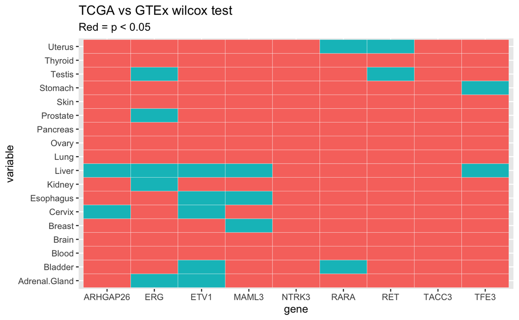

```r
compare_tcga_gtex_heat %>% melt(.) %>%
  mutate(gene = rep(c("ERG", "MAML3", "TFE3", "RARA", "TACC3", "RET", "ETV1", "NTRK3", "ARHGAP26"), times = 18), .before = variable) %>%
  mutate(groups = cut(.$value, breaks = c(1, 0.05, 0))) %>%
  ggplot(., aes(gene, variable, fill = groups)) +
  geom_tile(colour = "white", linetype = 1) +
  scale_fill_discrete(breaks = levels(groups)) +
  labs(title = "TCGA vs GTEx wilcox test", subtitle = "Red = p < 0.05")
```

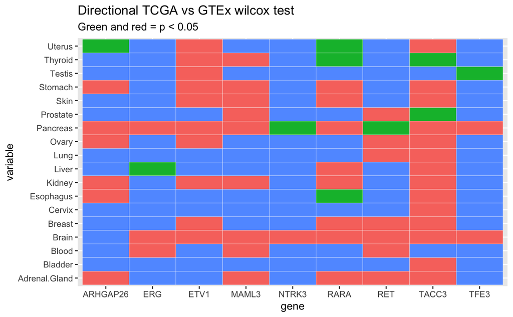

```r
compare_tcga_gtex_heat_sided %>% melt(.) %>%
  mutate(gene = rep(c("ERG", "MAML3", "TFE3", "RARA", "TACC3", "RET", "ETV1", "NTRK3", "ARHGAP26"), times = 18), .before = variable) %>%
  mutate(groups = cut(.$value, breaks = c(1, 0.05, 0.001, 0))) %>%
  ggplot(., aes(gene, variable, fill = groups)) +
  geom_tile(colour = "white", linetype = 1) +
  scale_fill_discrete(breaks = levels(groups)) +
  labs(title = "Directional TCGA vs GTEx wilcox test", subtitle = "Green and red = p < 0.05")
```

-Are fusions in cancers where the tissue is not normally expressed?

These are some of the questions driving this analysis.

-for an extra layer of complexity, if we want to copy an approach that filters out lowly expressed genes using a log2 expression threshold, we have to consider the differences in normalisation approaches.

# approach 1: recount2

-on scaled data (not log2) normalised = (coverage/AUC) *target library size (assumed 40 million) filter: mean > 0.5 (however we have not been scaling by 40 million - we've been scaling by 1 million)

# approach 2: gene distribution paper

-filters lowly expressed genes via: >25% of samples log2 value < 1 -unclear what method of normalisation used

# approach 3: edgeR filter by expression function

https://f1000research.com/articles/5-1408 -on cpm data (counts per million) -gene needs 10 read counts minimum in certain number of samples -10/median library size in millions = threshold -keep genes that have cpm above threshold in >= 3 samples

-all of these methods are designed to for DEG analysis which includes all genes - important to filter out ones of no biological interest -however this method takes a gene as input - presumably one of biological importance -difference between a gene that is not expressed and one that is lowly expressed

```r
tacc3_combined %>%
  ggplot(aes(x = Tissue, y = log2_auc_norm, fill = has_cancer)) +
  geom_boxplot() +
  theme(axis.text.x = element_text(angle = 90, vjust = 0.5, hjust=1)) +
  facet_wrap(~ has_cancer)
```

## applying approaches: TACC3 as case study

# approach 1: recount2

```r
tacc3_combined %>%
  group_by(Tissue, cancer_status) %>%
  summarise(mean_norm = mean(auc_norm)) %>%
  filter(mean_norm < 0.5)

tacc3_combined %>%
  group_by(Tissue, cancer_status) %>%
  summarise(mean_log_norm = mean(log2_auc_norm)) %>%
  filter(mean_log_norm < 0.5)
```

-all means higher than 0.5, doesn't filter out any cancers

```r
all_genes %>%
  group_by(gene, Tissue, cancer_status) %>%
  summarise(mean_norm = mean(auc_norm)) %>%
  filter(mean_norm < 0.5)

all_genes %>%
  group_by(gene, Tissue, cancer_status) %>%
  summarise(mean_norm = mean(auc_norm*40)) %>%
  filter(mean_norm < 0.5)
```

-filters out 68 cases total: -mostly ALK -if I scale by 40 million - like it should be - only filter out 1 case

# approach2: gene distrib

```r
tacc3_combined %>%
  group_by(Tissue, cancer_status) %>%
  filter(quant25 <= 1) %>%
  distinct(Tissue)
```

-filters out GTEx muscle

```r
all_genes %>%
  ungroup() %>%
  group_by(gene, Tissue, cancer_status) %>%
  filter(quant25 <= 1) %>%
  distinct(gene)
```

-filters out 241 cases

# approach3: edgeR

```r
tacc3_counts %>%
  group_by(Tissue, cancer_status) %>%
  mutate(median_auc = 10/(median(auc)/1e6)) %>%
  filter(auc_norm > median_auc) %>%
  summarise(n = n()) %>%
  filter(n < 3)
gtex_tacc3_counts %>%
  group_by(Tissue, cancer_status) %>%
  mutate(median_auc = 10/(median(auc)/1e6)) %>%
  filter(auc_norm > median_auc) %>%
  summarise(n = n()) %>%
  filter(n < 3)
```

-filters out 3 normal tissues: skin, soft tissue, thymus

```r
all_genes %>%
  filter(has_cancer != "GTEx") %>%
  group_by(gene, Tissue, cancer_status) %>%
  mutate(median_auc = 10/(median(Counts/auc_norm)/1e6)) %>%
  filter(auc_norm > median_auc) %>%
  summarise(n = n()) %>%
  filter(n < 3)
all_genes %>%
  filter(has_cancer == "GTEx") %>%
  group_by(Tissue, cancer_status) %>%
  mutate(median_auc = 10/(median(Counts/auc_norm)/1e6)) %>%
  filter(auc_norm > median_auc) %>%
  summarise(n = n()) %>%
  filter(n < 3)
```

-filters out 7 cases

# discussion

These methods aren't actually really what I want - they don't filter out enough cancers to really be effective

# more precise comparisons between cancers

log fold change?

# log2 fold change

```r
tacc3_combined %>%
  ungroup() %>%
  group_by(cancer_status) %>%
  mutate(status_median_auc = median(log2_auc_norm)) %>%
  ungroup() %>%
  group_by(cancer_status, Project_ID) %>%
  mutate(median_auc = median(log2_auc_norm), fc_status = median_auc - status_median_auc) %>%
  distinct(fc_status) %>%
  ggplot(aes(x = Project_ID, y = fc_status, colour = cancer_status)) +
  geom_point() +
  theme(axis.text.x = element_text(angle = 90, vjust = 0.5, hjust=1))

#this is difference between the cancers
tacc3_combined %>%
  ungroup() %>%
  filter(has_cancer == "Cancer") %>%
  mutate(status_median_auc = median(log2_auc_norm)) %>%
  group_by(Project_ID) %>%
  mutate(median_auc = median(log2_auc_norm), fc_status = median_auc - status_median_auc) %>%
  distinct(fc_status) %>%
  ggplot(aes(x = Project_ID, y = fc_status)) +
  geom_point() +
  theme(axis.text.x = element_text(angle = 90, vjust = 0.5, hjust=1))
#just cancers with fusions
tacc3_combined %>%
  ungroup() %>%
  filter(has_cancer == "Cancer") %>%
  mutate(status_median_auc = median(log2_auc_norm)) %>%
  group_by(Project_ID) %>%
  mutate(median_auc = median(log2_auc_norm), fc_status = median_auc - status_median_auc) %>%
  filter(Tissue == "Bladder" | Tissue == "Breast" | Tissue == "Cervix" | Tissue == "Esophagus" | Tissue == "Brain" | Tissue == "Head and Neck" | Tissue == "Kidney" | Tissue == "Blood" | Tissue == "Liver" | Tissue == "Lung" | Tissue == "Stomach") %>%
  distinct(fc_status) %>%
  ggplot(aes(x = Project_ID, y = fc_status)) +
  geom_point() +
  theme(axis.text.x = element_text(angle = 90, vjust = 0.5, hjust=1))
#non fusion cancers
tacc3_combined %>%
  ungroup() %>%
  filter(has_cancer == "Cancer") %>%
  mutate(status_median_auc = median(log2_auc_norm)) %>%
  group_by(Project_ID) %>%
  mutate(median_auc = median(log2_auc_norm), fc_status = median_auc - status_median_auc) %>%
  filter(Tissue != "Bladder" | Tissue != "Breast" | Tissue != "Cervix" | Tissue != "Esophagus" | Tissue != "Brain" | Tissue != "Head and Neck" | Tissue != "Kidney" | Tissue != "Blood" | Tissue != "Liver" | Tissue != "Lung" | Tissue != "Stomach") %>%
  distinct(fc_status) %>%
  ggplot(aes(x = Project_ID, y = fc_status)) +
  geom_point() +
  theme(axis.text.x = element_text(angle = 90, vjust = 0.5, hjust=1))
```

no I want median(cancer) - median(normal) - what I've got here is their distance from overall tissue median

```r
tacc3_combined %>%
  ungroup() %>%
  filter(has_cancer != "Normal") %>%
  group_by(Tissue) %>%
  mutate(status_median_auc = median(log2_auc_norm)) %>%
  ungroup() %>%
  group_by(Tissue, has_cancer) %>%
  mutate(median_auc = median(log2_auc_norm), fc_status = median_auc - status_median_auc) %>%
  distinct(fc_status, status_median_auc) %>%
  ggplot(aes(x = Tissue, y = fc_status, colour = has_cancer)) +
  geom_point() +
  geom_point(aes(x = Tissue, y = status_median_auc), colour = "black") +
  theme(axis.text.x = element_text(angle = 90, vjust = 0.5, hjust=1))
```

using known fusion rate?

## end of explanation

-let's try using uni approach

```r
model_1 <- lm(log2_auc_norm ~ fusion + is_expressed + fusion:is_expressed, data = filter(erg_combined, cancer_status != "GTEx", cancer_status != "Normal"), contrasts = list(fusion = "contr.sum", is_expressed = "contr.sum"))

model_1

anova(model_1, type = 3) #weird this should work: error is $ operator invalid for atomic vectors
```

# chisquare analysis

http://www.sthda.com/english/wiki/chi-square-test-of-independence-in-r maybe chi-square contingency analysis? compares frequencies of 2 categorical explan and response say that explan is is_expressed, and response is fusion it tests null hyp that row and column values indep, alt not indep

# cancer: fusion vs is expressed

```r
contingency_1 <- table(filter(erg_combined, cancer_status != "GTEx", cancer_status != "Normal")$fusion, filter(erg_combined, cancer_status != "GTEx", cancer_status != "Normal")$is_expressed)
chisq.test(contingency_1)
```

```r
all_genes$fusion <- as.factor(all_genes$fusion)
all_genes$is_expressed <- as.factor(all_genes$is_expressed)
all_genes
levels(all_genes$is_expressed)
```

```r
all_genes %>%
  filter(has_cancer == "Cancer") %>%
  distinct

all_genes %>%
  filter(has_cancer == "Cancer") %>%
  split(f = list(as.character(.$gene))) %>%
  map(~chisq.test(.x$fusion, .x$is_expressed))
```

-not all of them filter out cancers - so won't work like this

-so this says is assoc?

```r
#install.packages("corrplot")
library(corrplot)
corrplot(chisq.test(contingency_1)$residuals, is.cor = FALSE)
```

-positive residuals blue - position association -negative residuals red - no association -so fusion is associated with cancer being normally expressed

-yay I think that told me something good

# what if we do fusion and gtex is expressed

-oh that didn't work - wants stuff of the same length

```r
contingency_2 <- table(filter(expression_erg, cancer_status != "GTEx", cancer_status != "Normal")$fusion, filter(expression_erg, cancer_status == "GTEx")$is_expressed)
chisq.test(contingency_2)
corrplot(chisq.test(contingency_2)$residuals, is.cor = FALSE)
```

# tcga and gtex?

no same problem

```r
contingency_3 <- table(filter(expression_erg, cancer_status != "GTEx", cancer_status != "Normal")$is_expressed, filter(expression_erg, cancer_status == "GTEx")$is_expressed)
chisq.test(contingency_3)
corrplot(chisq.test(contingency_3)$residuals, is.cor = FALSE)
```

# thoughts on application

-not sure if I want to split this by cancer type? -I need to get the factorial anova working

how can I work around problem? -maybe I could add to the fusion and is_expressed columns so covers gtex and normal and cancer -or maybe that's the only test I want for this

```r
expression_erg
```

```r
all_genes %>%
  ggplot(aes(x = gene, fill = fusion)) +
  geom_bar(position = "fill") +
  facet_wrap(~ is_expressed)
```

```r
#early break
expression_function_mutate(erg_combined) %>% filter(quant25 < 1) %>% distinct(fusion) #1 (cancer)
expression_function_mutate(maml3_combined) %>% filter(quant25 < 1) %>% distinct(fusion) #2 (cancer)
expression_function_mutate(tfe3_combined) %>% filter(quant25 < 1) %>% distinct(fusion) #nothing
expression_function_mutate(tmprss2_combined) %>% filter(quant25 < 1) %>% distinct(fusion) #kirp, (25 cases including normal)
expression_function_mutate(rara_combined) %>% filter(quant25 < 1) %>% distinct(fusion) # nothing
#middle break
expression_function_mutate(tacc3_combined) %>% filter(quant25 < 1) %>% distinct(fusion) #nothing
expression_function_mutate(ret_combined) %>% filter(quant25 < 1) %>% distinct(fusion) #fusion in thyroid, colon, ovarian, lung, aml (49 cases)
expression_function_mutate(etv1_combined) %>% filter(quant25 < 1) %>% distinct(fusion) #7
expression_function_mutate(ntrk3_combined) %>% filter(quant25 < 1) %>% distinct(fusion) #fusion in breast invasive, colon, skin, pancreas, cervix, head and neck, 43 total
expression_function_mutate(alk_combined) %>% filter(quant25 < 1) %>% distinct(fusion) #fusion in thyroid, sarcoma, skin, bladder, krp, lung a, rectum, 62 cases
expression_function_mutate(arhgap26_combined) %>% filter(quant25 < 1) %>% distinct(fusion) #nothing
```

hmmm not sure it's a pattern but it's something only 1 fusions in cancers that had early breakpoints and 25% < 1 -not that early breakpoints had a lot of cancers with exp < 1, 2 genes had 0, tmprss2 had 25 cases though

same as early, 2 middle genes had nothing -but there were more cases in the other genes - including in fusions -could just be very gene specific -would need to compare more than 5 genes for each to really know -maybe I should try it by tissue so get the gtex - see if it happens there -but yeah if I followed the paper - these are the cancers I wouldn't look at

-let's look more closely at the cancers with fusions where quant25 < 1 tmprss2 - kidney renal pap - nothing really interesting ret - thyroid - hey hey it's bimodalish - wasn't picked up by test but wilcox test showed them different ret - colon - peak is like at 0, but fusion is towards the end - also beyond gtex ret - ovary - again not bimodal by the test but does have that dip - which is where the fusion is ret - lung - again it's a little bit bimodal - this time fusions are in the dip ret - blood - yeah that's the bad <0 one - but again distrib has that little dip ntrk3 - breast - it's at the end past the gtex ntrk3 - colon - most of it is very low, fusion at end ntrk3 - skin - also has a dip - fusion is at very end though - way past dip - dip is at around 0 ntrk3 - pancreas - big tcga and gtex overlap - fusion at v. end ntrk3 - cervix - fusion at very end - part way through the gtex ntrk3 - head mostly towards end alk-

anyway what do I want to do with this info? well for one I think I want a more subtle test for bimodality a way just to show dips because I'm seeing fusions at dips also whne bulk of samples low expressed - anything high is automatically interesting - want a way to flag them

```r
tmprss2_counts %>%
  filter(Cancer == "Kidney Renal Papillary Cell Carcinoma") %>%
  ggplot(aes(x = log2_auc_norm, fill = cancer_status)) +
  geom_density(alpha = 0.4) +
  geom_vline(aes(xintercept = log2_auc_norm), data=. %>% filter(fusion == "Fusion")) +
  labs(title = "TMPRSS2 - KIRP")

ret_counts %>%
  filter(Cancer == "Thyroid Carcinoma") %>%
  ggplot(aes(x = log2_auc_norm, fill = cancer_status)) +
  geom_density(alpha = 0.4) +
  geom_vline(aes(xintercept = log2_auc_norm), data=. %>% filter(fusion == "Fusion")) +
  labs(title = "RET - Thyroid")

ret_counts %>%
  filter(Cancer == "Colon Adenocarcinoma") %>%
  ggplot(aes(x = log2_auc_norm, fill = cancer_status)) +
  geom_density(alpha = 0.4) +
  geom_vline(aes(xintercept = log2_auc_norm), data=. %>% filter(fusion == "Fusion")) +
  labs(title = "RET - Colon")

ret_counts %>%
  filter(Cancer == "Ovarian Serous Cystadenocarcinoma") %>%
  ggplot(aes(x = log2_auc_norm, fill = cancer_status)) +
  geom_density(alpha = 0.4) +
  geom_vline(aes(xintercept = log2_auc_norm), data=. %>% filter(fusion == "Fusion")) +
  labs(title = "RET - Ovary")

ret_counts %>%
  filter(Cancer == "Lung Adenocarcinoma") %>%
  ggplot(aes(x = log2_auc_norm, fill = cancer_status)) +
  geom_density(alpha = 0.4) +
  geom_vline(aes(xintercept = log2_auc_norm), data=. %>% filter(fusion == "Fusion")) +
  labs(title = "RET - Lung Adenocarcinoma")

ret_counts %>%
  filter(Cancer == "Acute Myeloid Leukemia") %>%
  ggplot(aes(x = log2_auc_norm, fill = cancer_status)) +
  geom_density(alpha = 0.4) +
  geom_vline(aes(xintercept = log2_auc_norm), data=. %>% filter(fusion == "Fusion")) +
  labs(title = "RET - Blood")

ntrk3_counts %>%
  filter(Cancer == "Breast Invasive Carcinoma") %>%
  ggplot(aes(x = log2_auc_norm, fill = cancer_status)) +
  geom_density(alpha = 0.4) +
  geom_vline(aes(xintercept = log2_auc_norm), data=. %>% filter(fusion == "Fusion")) +
  labs(title = "NTRK3 - Breast")

ntrk3_counts %>%
  filter(Cancer == "Colon Adenocarcinoma") %>%
  ggplot(aes(x = log2_auc_norm, fill = cancer_status)) +
  geom_density(alpha = 0.4) +
  geom_vline(aes(xintercept = log2_auc_norm), data=. %>% filter(fusion == "Fusion")) +
  labs(title = "NTRK3 - Colon")

ntrk3_counts %>%
  filter(Cancer == "Skin Cutaneous Melanoma") %>%
  ggplot(aes(x = log2_auc_norm, fill = cancer_status)) +
  geom_density(alpha = 0.4) +
  geom_vline(aes(xintercept = log2_auc_norm), data=. %>% filter(fusion == "Fusion")) +
  labs(title = "NTRK3 - Skin")

ntrk3_counts %>%
  filter(Cancer == "Pancreatic Adenocarcinoma") %>%
  ggplot(aes(x = log2_auc_norm, fill = cancer_status)) +
  geom_density(alpha = 0.4) +
  geom_vline(aes(xintercept = log2_auc_norm), data=. %>% filter(fusion == "Fusion")) +
  labs(title = "NTRK3 - Pancreas")

ntrk3_counts %>%
  filter(Cancer == "Cervical Squamous Cell Carcinoma and Endocervical Adenocarcinoma") %>%
  ggplot(aes(x = log2_auc_norm, fill = cancer_status)) +
  geom_density(alpha = 0.4) +
  geom_vline(aes(xintercept = log2_auc_norm), data=. %>% filter(fusion == "Fusion")) +
  labs(title = "NTRK3 - Cervix")

ntrk3_counts %>%
  filter(Cancer == "Head and Neck Squamous Cell Carcinoma") %>%
  ggplot(aes(x = log2_auc_norm, fill = cancer_status)) +
  geom_density(alpha = 0.4) +
  geom_vline(aes(xintercept = log2_auc_norm), data=. %>% filter(fusion == "Fusion")) +
  labs(title = "NTRK3 - Head")
```

# this work

```r
expression_erg <- expression_function_mutate2(erg_combined)
expression_erg
```

# visualisation and functionality

```r
erg_combined %>%
  ggplot(aes(x = is_expressed, y = log2_auc_norm, fill = cancer_status)) +
  geom_boxplot() +
  geom_hline(yintercept = 1) +
  facet_wrap(~ Tissue)

erg_combined %>%
  ggplot(aes(x = is_expressed, y = log2_auc_norm, fill = cancer_status)) +
  geom_violin() +
  geom_hline(yintercept = 1) +
  facet_wrap(~ Tissue)
```

```r
all_genes %>%
  filter(is_expressed == "Not normally expressed") %>%
  ggplot(aes(x = gene, y = log2_auc_norm, fill = cancer_status)) +
  geom_boxplot() +
  geom_hline(yintercept = 1) +
  facet_wrap(~ Tissue)

all_genes %>%
  filter(is_expressed == "Not normally expressed") %>%
  ggplot(aes(x = gene, y = log2_auc_norm, fill = cancer_status)) +
  geom_violin() +
  geom_hline(yintercept = 1) +
  facet_wrap(~ Tissue)
```

-could do an if else: if gene not normally expressed (cancer) - potential fusion anything greater than 1 (overexpressed) -see if I can use distribution shape to inform this a bit more -also connect to outliers

# analysis - where are the fusions?

-big question: are the fusions in cancers that are normally expressed but the gtex/normal is not?

```r
all_genes
```

```r
expression_function_mutate_for_all <- function(gene) {
  q = c(0.25, 0.5, 0.75)
  counts <- gene
  counts <- counts %>%
    group_by(gene, Tissue, cancer_status) %>%
    mutate(min = min(log2_auc_norm),
            quant25 = quantile(log2_auc_norm, probs = 0.25),
            quant50 = quantile(log2_auc_norm, probs = 0.5),
            quant75 = quantile(log2_auc_norm, probs = 0.75),
            max = max(log2_auc_norm),
            outlier = (quant75 + 1.5*(quant75 - quant25)))
  counts <- counts %>%
    group_by(gene, Tissue, cancer_status) %>%
    mutate(is_outlier = ifelse(log2_auc_norm >= outlier, T, F))
  counts %>% mutate(is_expressed = ifelse(quant25 < 1, "Not normally expressed", "Normally expressed"))
}
```

```r
all_genes <- expression_function_mutate_for_all(all_genes)
all_genes
```

```r
all_genes %>%
  filter(fusion == "Fusion") %>%
  group_by(gene, Tissue, is_expressed) %>%
  summarise(n = n(is_expressed))
```

-this isn't working -maybe I want a stat test now -I want to know if there's a link between if gene is expressed and fusion -that goes for expressed in cancer, normal, gtex -I want to know if there's a link between gene not expressed (more so for cancer) and fusions being outliers - that would be cool

-let's try a factorial anova fusion and is expressed

```r
expression_erg %>%
  filter(cancer_status != "GTEx", cancer_status != "Normal") %>%
  ggplot(aes(x = fusion, y = log2_auc_norm)) +
  geom_boxplot()

expression_erg %>%
  filter(cancer_status != "GTEx", cancer_status != "Normal") %>%
  ggplot(aes(x = is_expressed, y = log2_auc_norm)) +
  geom_boxplot()
```

https://homepages.inf.ed.ac.uk/bwebb/statistics/Factorial_ANOVA_in_R.pdf

```r
aov_1 = aov(log2_auc_norm ~ fusion * is_expressed, data = filter(expression_erg, cancer_status != "GTEx", cancer_status != "Normal"))
aov_1
TukeyHSD(aov_1)
```

-odd it's not showing the combined

-let's try using uni approach

```r
model_1 <- lm(log2_auc_norm ~ fusion + is_expressed + fusion:is_expressed, data = filter(expression_erg, cancer_status != "GTEx", cancer_status != "Normal"), contrasts = list(fusion = "contr.sum", is_expressed = "contr.sum"))

model_1

anova(model_1, type = 3) #weird this should work: error is $ operator invalid for atomic vectors
```

```r
expression_erg_fac <- expression_erg
expression_erg_fac$fusion <- as.factor(expression_erg_fac$fusion)
expression_erg_fac$is_expressed <- as.factor(expression_erg_fac$is_expressed)
```

```r
model_1a <- lm(log2_auc_norm ~ fusion + is_expressed + fusion:is_expressed, data = filter(expression_erg_fac, cancer_status != "GTEx", cancer_status != "Normal"), contrasts = list(fusion = "contr.sum", is_expressed = "contr.sum"))

model_1a

anova(model_1a, type = 3)
```

no that didn't fix it

maybe correlation would be a better approach? I think that's for numerical actually

# chisquare analysis

http://www.sthda.com/english/wiki/chi-square-test-of-independence-in-r maybe chi-square contingency analysis? compares frequencies of 2 categorical explan and response say that explan is is_expressed, and response is fusion it tests null hyp that row and column values indep, alt not indep

# cancer: fusion vs is expressed

```r
contingency_1 <- table(filter(expression_erg, cancer_status != "GTEx", cancer_status != "Normal")$fusion, filter(expression_erg, cancer_status != "GTEx", cancer_status != "Normal")$is_expressed)
chisq.test(contingency_1)
```

-so this says is assoc?

```r
#install.packages("corrplot")
#library(corrplot)
corrplot(chisq.test(contingency_1)$residuals, is.cor = FALSE)
```

-positive residuals blue - position association -negative residuals red - no association -so fusion is associated with cancer being normally expressed

-yay I think that told me something good

# what if we do fusion and gtex is expressed

-oh that didn't work - wants stuff of the same length

```r
contingency_2 <- table(filter(expression_erg, cancer_status != "GTEx", cancer_status != "Normal")$fusion, filter(expression_erg, cancer_status == "GTEx")$is_expressed)
chisq.test(contingency_2)
corrplot(chisq.test(contingency_2)$residuals, is.cor = FALSE)
```

# tcga and gtex?

no same problem

```r
contingency_3 <- table(filter(expression_erg, cancer_status != "GTEx", cancer_status != "Normal")$is_expressed, filter(expression_erg, cancer_status == "GTEx")$is_expressed)
chisq.test(contingency_3)
corrplot(chisq.test(contingency_3)$residuals, is.cor = FALSE)
```

# thoughts on application

-not sure if I want to split this by cancer type? -I need to get the factorial anova working

how can I work around problem? -maybe I could add to the fusion and is_expressed columns so covers gtex and normal and cancer -or maybe that's the only test I want for this

```r
expression_erg
```

```r
all_genes %>%
  ggplot(aes(x = gene, fill = fusion)) +
  geom_bar(position = "fill") +
  facet_wrap(~ is_expressed)
```

```r
erg_combined %>%
  ggplot(aes(x = Tissue, y = ))
```

```r
#need a loop or apply
if (expression_erg$quant25 < 1) {
  print("Not normally expressed")
} else {
  print("Normally expressed")
}
```

-would prefer something neat

```r
#old version
#expression_function <- function(gene) {
  counts <-  gene %>%
    filter(cancer_status == "Cancer") %>%
    group_by(Cancer) %>%
    distinct(Cancer) %>%
    .[order(.$Cancer),]
  cancer <- gene %>%
    filter(cancer_status == "Cancer") %>%
    split(f = list(as.character(.$Cancer))) %>%
   map(~quantile(.x$log2_auc_norm)) %>% #it won't let me select a specific quartile
    unlist(., .$Cancer) %>%
    data.frame(.)
  #can i do it for gtex? and then compare?
}
```

```r
erg_combined %>%
  filter(cancer_status == "Cancer") %>%
  split(f = list(as.character(.$Cancer))) %>%
  map(~rosnerTest(.x$log2_auc_norm, k = 10)$all.stats)
  unlist(., .$Cancer) %>%
  data.frame(.)
```

-are the genes with low expression (25% < 1) also more skewed??

```r
all_genes
```

```r
all_genes %>%
  ggplot(aes(x = gene, y = log2_auc_norm, colour = fusion)) +
  geom_boxplot(alpha = 0.4) +
  facet_wrap(~ cancer_status)

all_genes %>% #why is the gtex distrib the exact same for all 10 of these genes???
  filter(cancer_status == "GTEx") %>%
  ggplot(aes(x = Tissue, y = log2_auc_norm)) +
  geom_boxplot(alpha = 0.4)
```

# can I mess with percentiles?

```r
tacc3_combined %>% filter(is_expressed == "Not normally expressed") %>% distinct(Tissue, cancer_status)
```

-when fusions are in not expressed genes - are they outliers?? not necessarily ret thyroid - 31 not outliers, but 2 outliers

```r
all_genes %>% filter(fusion == "Fusion", is_expressed == "Not normally expressed") %>% group_by(gene, Cancer, is_outlier) %>% summarise(n())
```

```r
ret_combined %>%
  filter(has_cancer == "Cancer") %>%
  ggplot(aes(x = log2_auc_norm)) +
  geom_density() +
  geom_vline(aes(xintercept = log2_auc_norm), data=. %>% filter(fusion == "Fusion"))
```

# want a way to extract what quantile expression becomes > 1

```r
all_genes %>%
  filter(has_cancer == "Cancer") %>%
  filter(is_expressed == "Not normally expressed") %>%
  ungroup() %>%
  group_by(gene, Project_ID) %>%
  split(f = list(as.character(gene))) %>%
  map(~quantile(.x))
```

-maybe if then or something like that? when percentile > 1 - return percentile

```r
quantile(filter(erg_combined, has_cancer == "Cancer", is_expressed == "Not normally expressed")$log2_auc_norm, 1/100)
```

# identify cancers that are expressed when matching gtex/normal is not

-can visually id but not able to pull it out yet

-want something that says if the is_expressed matches for the groups, then no change - if don't match, then change -kinda like a categorical anova funnily enough -think I need to google how to do this

```r
erg_combined %>%
  ungroup() %>%
  group_by(Tissue, cancer_status, is_expressed) %>%
  distinct(Tissue) %>%
  .[order(.$Tissue),]

erg_combined %>%
  ungroup() %>%
  group_by(Tissue, cancer_status) %>%
  select(Tissue, cancer_status, is_expressed) %>%
  distinct(is_expressed) %>%
  .[order(.$Tissue),]
  #mutate(change = cancer_status)
```

-erg blood cancer, skin cancer (but normal was expressed)

# another way to identify lowly expressed genes

```r
rbind(tacc3_counts %>%
  group_by(has_cancer) %>%
  summarise(median_auc = 10/(median(auc)/1e6), median_mapped = 10/(median(mapped)/1e6)), gtex_tacc3_counts %>%
  group_by(has_cancer) %>%
  summarise(median_auc = 10/(median(auc)/1e6), median_mapped = 10/(median(mapped)/1e6)))
```

```r
tacc3_combined %>%
  ggplot(aes(x = Tissue, y = log2_auc_norm, fill = has_cancer)) +
  geom_boxplot() +
  geom_hline(aes(yintercept = 0.0016))
```